# IODS course project

Matthias Aulbach

# About the project

# Open Data Course

This is a course to get started on *Open Data Science*, an issue very much pushed by the University of Helsinki. I’m particularly interested in learning to use R for analyzing my research data that I will collect in the course of my PhD.

## Assignments

It seems like there’s going to be a lot of work to be done throughout the course but I guess that’s the only way to really learn how to use all the tools. **No pain, no gain!**

The assignments include:

1. Datacamp exercises
2. R exercises
3. github
   - uploading your exercises
   - providing a link to the repository

## Link to the github repository

Here’s the link to my github repository: https://github.com/matthiasaulbach/IODS-project/

# Exercise 2 - Regression

## Reading the data file into R

```r
students2014 <- read.table("D:/PhD University of Helsinki/Open Data Science/IODS-project/Data/learning2014.txt", sep = ",", header = TRUE)
```

## Getting an overview

```r
str(students2014)
```

```
## 'data.frame':    166 obs. of  7 variables:
##  $ gender  : Factor w/ 2 levels "F","M": 1 2 1 2 2 1 2 1 2 1 ...
##  $ age     : int  53 55 49 53 49 38 50 37 37 42 ...
##  $ attitude: int  37 31 25 35 37 38 35 29 38 21 ...
##  $ deep    : num  3.75 2.88 3.88 3.5 3.75 ...
##  $ stra    : num  3.38 2.75 3.62 3.12 3.62 ...
##  $ surf    : num  2.58 3.17 2.25 2.25 2.83 ...
##  $ points  : int  25 12 24 10 22 21 21 31 24 26 ...
```

```r
dim(students2014)
```

```
## [1] 166   7
```

We have a dataset of 166 observations of 7 variables (gender, age, attitude, deep, stra, surf, points) The variables “deep”, “stra”, and “surf” have been aggregated over different items and describe different learning styles The variable attitude measures the attitude towards the course The variable points measure the total amount of points in the course

## Plotting variables against each other with different genders in different colors

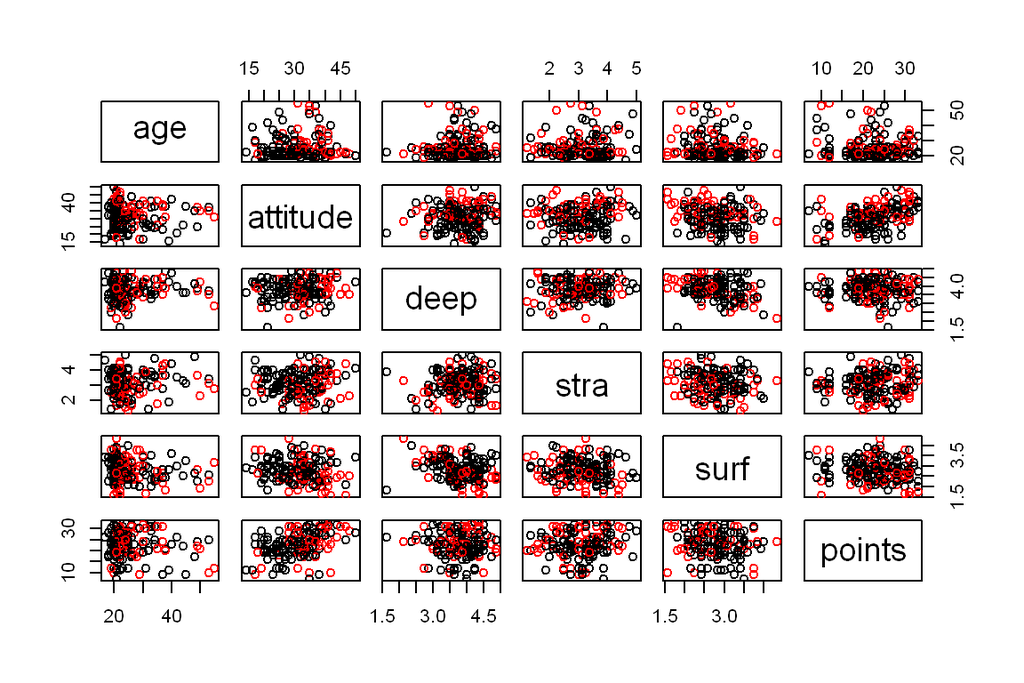

```r
pairs (students2014[-1], col = students2014$gender)
```

## Summary of the data

```r
summary(students2014)
```

```
##  gender       age           attitude          deep            stra
##  F:110   Min.   :17.00   Min.   :14.00   Min.   :1.625   Min.   :1.250
##  M: 56   1st Qu.:21.00   1st Qu.:26.00   1st Qu.:3.500   1st Qu.:2.625
##          Median :22.00   Median :32.00   Median :3.875   Median :3.188
##          Mean   :25.51   Mean   :31.43   Mean   :3.796   Mean   :3.121
##          3rd Qu.:27.00   3rd Qu.:37.00   3rd Qu.:4.250   3rd Qu.:3.625
##          Max.   :55.00   Max.   :50.00   Max.   :4.875   Max.   :5.000
##       surf           points
##  Min.   :1.583   Min.   : 7.00
##  1st Qu.:2.417   1st Qu.:19.00
##  Median :2.833   Median :23.00
##  Mean   :2.787   Mean   :22.72
##  3rd Qu.:3.167   3rd Qu.:27.75
##  Max.   :4.333   Max.   :33.00
```

## Regression model with “points” as the target variable and “age”, “attitude”, and “stra” as prdeictors.

```r
my_model <- lm(points ~ age + attitude + stra, data = students2014)
summary (my_model)
```

```
##
## Call:
## lm(formula = points ~ age + attitude + stra, data = students2014)
##
## Residuals:
##      Min       1Q   Median       3Q      Max
## -18.1149  -3.2003   0.3303   3.4129  10.7599
##
## Coefficients:
##             Estimate Std. Error t value Pr(>|t|)
## (Intercept) 10.89543    2.64834   4.114 6.17e-05 ***
## age         -0.08822    0.05302  -1.664   0.0981 .
## attitude     0.34808    0.05622   6.191 4.72e-09 ***
## stra         1.00371    0.53434   1.878   0.0621 .
## ---
## Signif. codes:  0 '***' 0.001 '**' 0.01 '*' 0.05 '.' 0.1 ' ' 1
##
## Residual standard error: 5.26 on 162 degrees of freedom
## Multiple R-squared:  0.2182, Adjusted R-squared:  0.2037
## F-statistic: 15.07 on 3 and 162 DF,  p-value: 1.07e-08
```

“age” had an estimate of -0.089, “attitude” of 0.348, and “stra” of 1.00. The estimated intercept was 10.9. only the intercept and attitude reached statistical significance. The adjusted R-square statistics for the whole model is 0.204, with F=15.1, highly significant. The model will be re-run with the only significant predictor, “attitude”

```r
my_model2 <- lm(points ~ attitude, data=students2014)
summary (my_model2)
```

```
##
## Call:
## lm(formula = points ~ attitude, data = students2014)
##
## Residuals:
##      Min       1Q   Median       3Q      Max
## -16.9763  -3.2119   0.4339   4.1534  10.6645
##
## Coefficients:
##             Estimate Std. Error t value Pr(>|t|)
## (Intercept) 11.63715    1.83035   6.358 1.95e-09 ***
## attitude     0.35255    0.05674   6.214 4.12e-09 ***
## ---
## Signif. codes:  0 '***' 0.001 '**' 0.01 '*' 0.05 '.' 0.1 ' ' 1
##
## Residual standard error: 5.32 on 164 degrees of freedom
## Multiple R-squared:  0.1906, Adjusted R-squared:  0.1856
## F-statistic: 38.61 on 1 and 164 DF,  p-value: 4.119e-09
```

The estimate of the intercept is highly significant at a value of 11.6. The estimate of attitude is highly significant at a value of 0.353. The adjusted R-square statistics for the whole model is 0.186, with F=38,6, highly significant. Attitude about the course has significant positive predicitve power for the points in the course.

## Plotting Residuals versus Fitted Values, Normal QQ-Plot, and Residuals vs Leverage

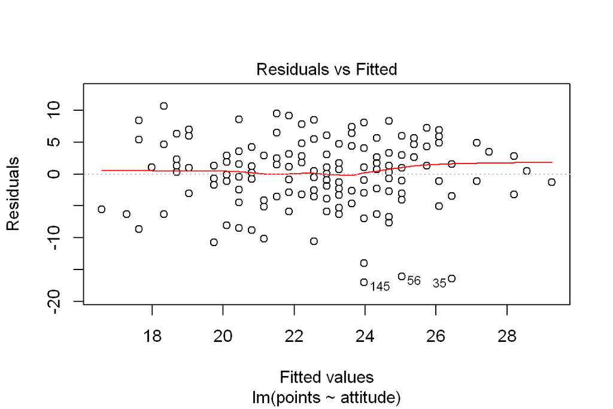

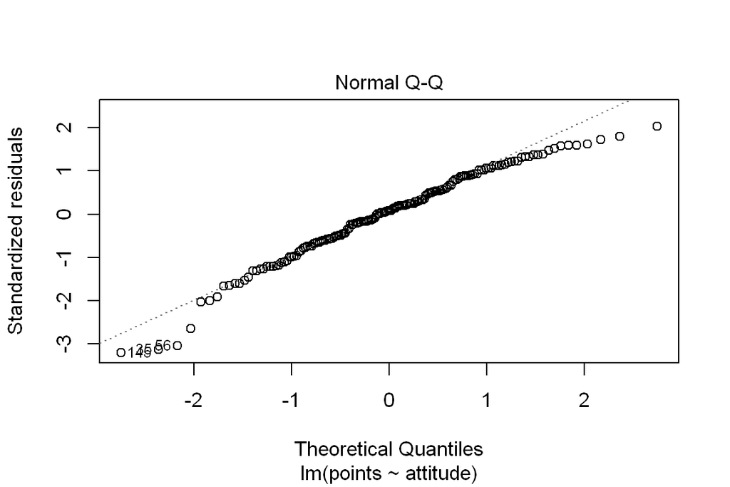

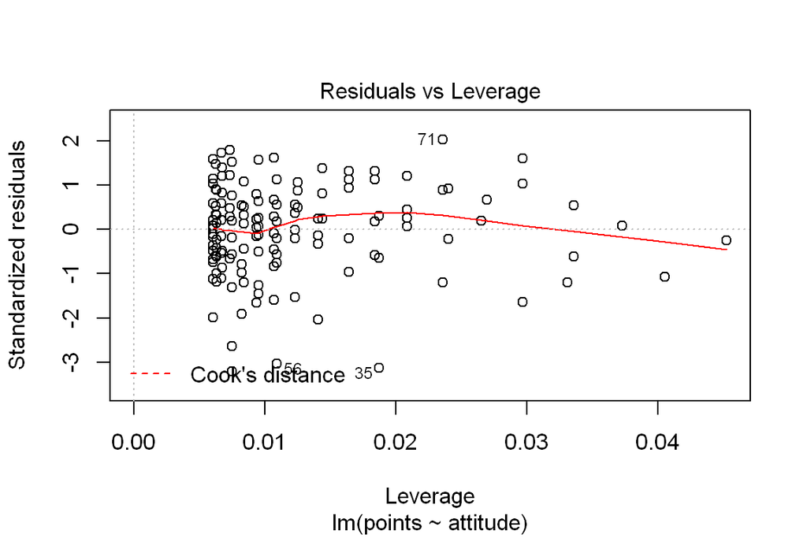

```r
plot (my_model2, which = c(1, 2, 5))
```

In the first plot we can see that the red line is close to 0, indicating that the fit of the model does not depend on the amount of points: it works for high and low amounts of points The Q-Q-Plot show us that for the highest and lowest quantiles (below -2 and above 2), the prediction is not accurate, indicating that a linear model might not fit the data best. However, for the majority of data points, the linear model fits well The residuals vs leverage graph shows that there are no outliers that heavily influence our regression model; the red line is rather flat.

# Exercise 3 - Logistic regression

## loading the data file and checking the structure

```
## 'data.frame':    382 obs. of  35 variables:
##  $ school    : Factor w/ 2 levels "GP","MS": 1 1 1 1 1 1 1 1 1 1 ...
##  $ sex       : Factor w/ 2 levels "F","M": 1 1 1 1 1 2 2 1 2 2 ...
##  $ age       : int  18 17 15 15 16 16 16 17 15 15 ...
##  $ address   : Factor w/ 2 levels "R","U": 2 2 2 2 2 2 2 2 2 2 ...
##  $ famsize   : Factor w/ 2 levels "GT3","LE3": 1 1 2 1 1 2 2 1 2 1 ...
##  $ Pstatus   : Factor w/ 2 levels "A","T": 1 2 2 2 2 2 2 1 1 2 ...
##  $ Medu      : int  4 1 1 4 3 4 2 4 3 3 ...
##  $ Fedu      : int  4 1 1 2 3 3 2 4 2 4 ...
##  $ Mjob      : Factor w/ 5 levels "at_home","health",..: 1 1 1 2 3 4 3 3 4 3 ...
##  $ Fjob      : Factor w/ 5 levels "at_home","health",..: 5 3 3 4 3 3 3 5 3 3 ...
##  $ reason    : Factor w/ 4 levels "course","home",..: 1 1 3 2 2 4 2 2 2 2 ...
##  $ nursery   : Factor w/ 2 levels "no","yes": 2 1 2 2 2 2 2 2 2 2 ...
##  $ internet  : Factor w/ 2 levels "no","yes": 1 2 2 2 1 2 2 1 2 2 ...
##  $ guardian  : Factor w/ 3 levels "father","mother",..: 2 1 2 2 1 2 2 2 2 2 ...
```

[output cut: 21 more lines]

## Printing column names

```
##  [1] "school"     "sex"        "age"        "address"    "famsize"
##  [6] "Pstatus"    "Medu"       "Fedu"       "Mjob"       "Fjob"
## [11] "reason"     "nursery"    "internet"   "guardian"   "traveltime"
## [16] "studytime"  "failures"   "schoolsup"  "famsup"     "paid"
## [21] "activities" "higher"     "romantic"   "famrel"     "freetime"
## [26] "goout"      "Dalc"       "Walc"       "health"     "absences"
## [31] "G1"         "G2"         "G3"         "alc_use"    "high_use"
```

The data set consists of 35 variables with 382 participants. It consists of different information about students in math and Portuguese language courses (see names of the columns).

## Relationship between alcohol consumption and 4 predictors

I will study the relationship between alcohol consumption and the following four variables

1. sex
2. age
3. Pstatus (the cohabitation status of students’ parents)
4. romantic (whether the student is in a romantic relationship or not)

My hypotheses are as follows:

1. Boys are more likely to be heavy alcohol users than girls.
2. Older students drink more than younger students.
3. Students, whose parents live apart drink more than students whose parents live together.
4. Student in a romantic relationship drink less than students without a romantic relationship

## sex vs high_use

```r
sex_high_use <- CrossTable(alc$sex, alc$high_use)
```

```
##
##
##    Cell Contents
## |-------------------------|
## |                       N |
## | Chi-square contribution |
## |           N / Row Total |
## |           N / Col Total |
## |         N / Table Total |
## |-------------------------|
##
##
## Total Observations in Table:  382
##
##
##              | alc$high_use
##      alc$sex |     FALSE |      TRUE | Row Total |
## -------------|-----------|-----------|-----------|
##            F |       157 |        41 |       198 |
##              |     2.078 |     5.009 |           |
##              |     0.793 |     0.207 |     0.518 |
##              |     0.581 |     0.366 |           |
##              |     0.411 |     0.107 |           |
## -------------|-----------|-----------|-----------|
##            M |       113 |        71 |       184 |
##              |     2.236 |     5.390 |           |
##              |     0.614 |     0.386 |     0.482 |
##              |     0.419 |     0.634 |           |
##              |     0.296 |     0.186 |           |
## -------------|-----------|-----------|-----------|
## Column Total |       270 |       112 |       382 |
##              |     0.707 |     0.293 |           |
## -------------|-----------|-----------|-----------|
##
##
```

```r
g1 <- ggplot(alc, aes(x = sex, y = alc_use))
```

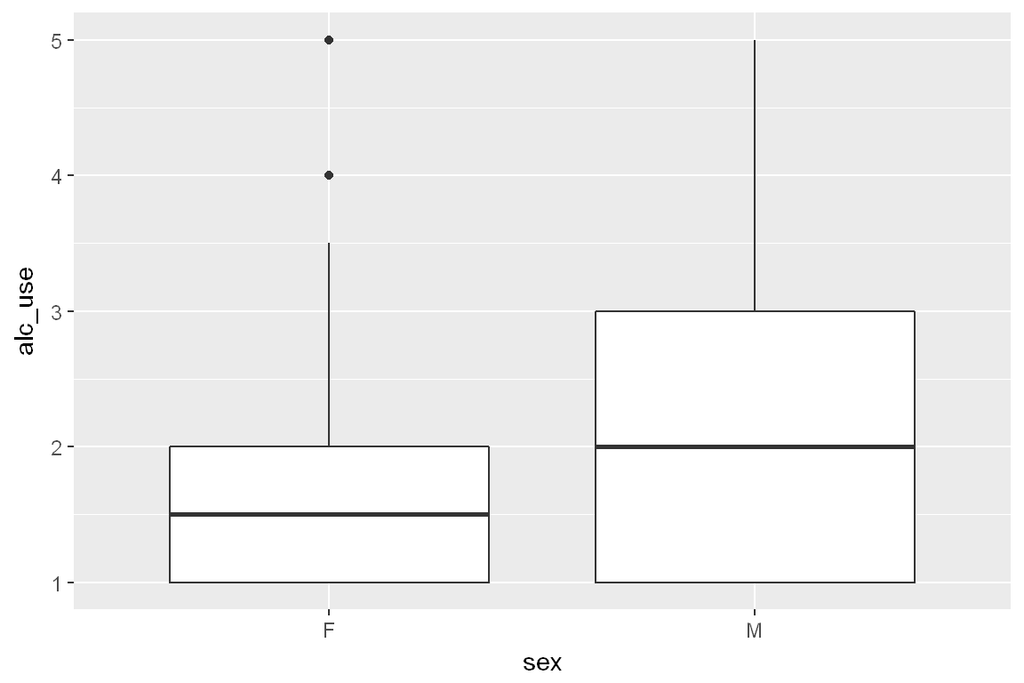

```r
g1 + geom_boxplot() + ylab("alc_use")
```

The boxplot shows that the CIs for males and females overlap largely. On average, males drink more than females.

The hypothesis is supported by the data. Males drink more on average and are more likely to be high users than females.

## age vs high_use

```r
g2 <- ggplot(alc, aes(x = high_use, y = age))
```

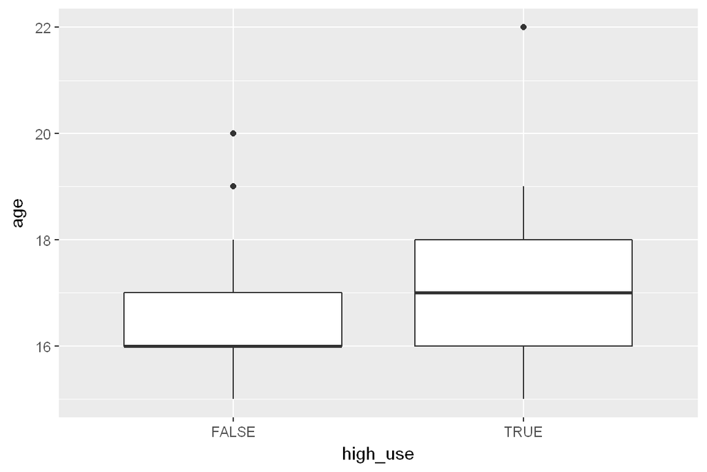

```r
g2 + geom_boxplot() + ylab ("age")
```

```r
reg1 <- lm (alc$alc_use ~ alc$age)
```

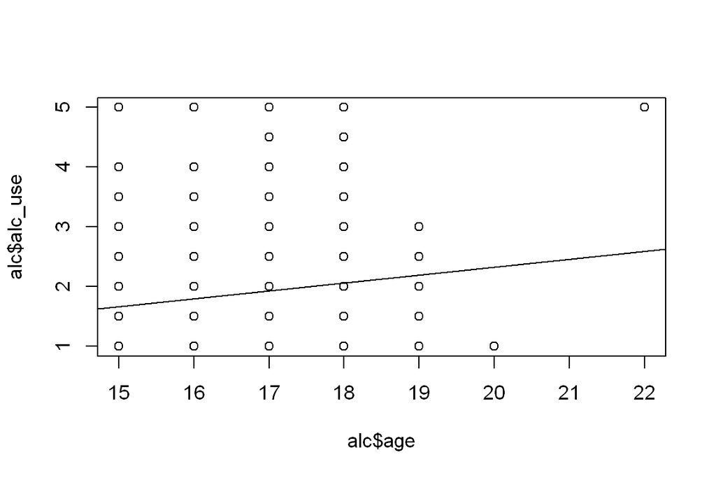

```r
g3 <- plot(alc$alc_use ~ alc$age)
abline (reg1)
```

Judging from the boxplot, high alcohol users are older than non-high-users on average. However, the confidence intervals overlap largely, indicating that there is no significant age difference between high alcohol users and non high alcohol users. The scatterplot alc_use vs age indicates a positive correlation between age and alcohol use. However, the variable alc_use is not truly numeric but rather categorical (even though it says differently in the description of the dataset). Therefore, the correlation doesn’t make much sense.

## Pstatus vs high_use

```r
CrossTable(alc$Pstatus, alc$high_use)
```

```
##
##
##    Cell Contents
## |-------------------------|
## |                       N |
## | Chi-square contribution |
## |           N / Row Total |
## |           N / Col Total |
## |         N / Table Total |
## |-------------------------|
##
##
## Total Observations in Table:  382
##
##
##              | alc$high_use
##  alc$Pstatus |     FALSE |      TRUE | Row Total |
## -------------|-----------|-----------|-----------|
##            A |        26 |        12 |        38 |
##              |     0.027 |     0.066 |           |
##              |     0.684 |     0.316 |     0.099 |
##              |     0.096 |     0.107 |           |
##              |     0.068 |     0.031 |           |
## -------------|-----------|-----------|-----------|
##            T |       244 |       100 |       344 |
##              |     0.003 |     0.007 |           |
##              |     0.709 |     0.291 |     0.901 |
##              |     0.904 |     0.893 |           |
##              |     0.639 |     0.262 |           |
## -------------|-----------|-----------|-----------|
## Column Total |       270 |       112 |       382 |
##              |     0.707 |     0.293 |           |
## -------------|-----------|-----------|-----------|
##
##
```

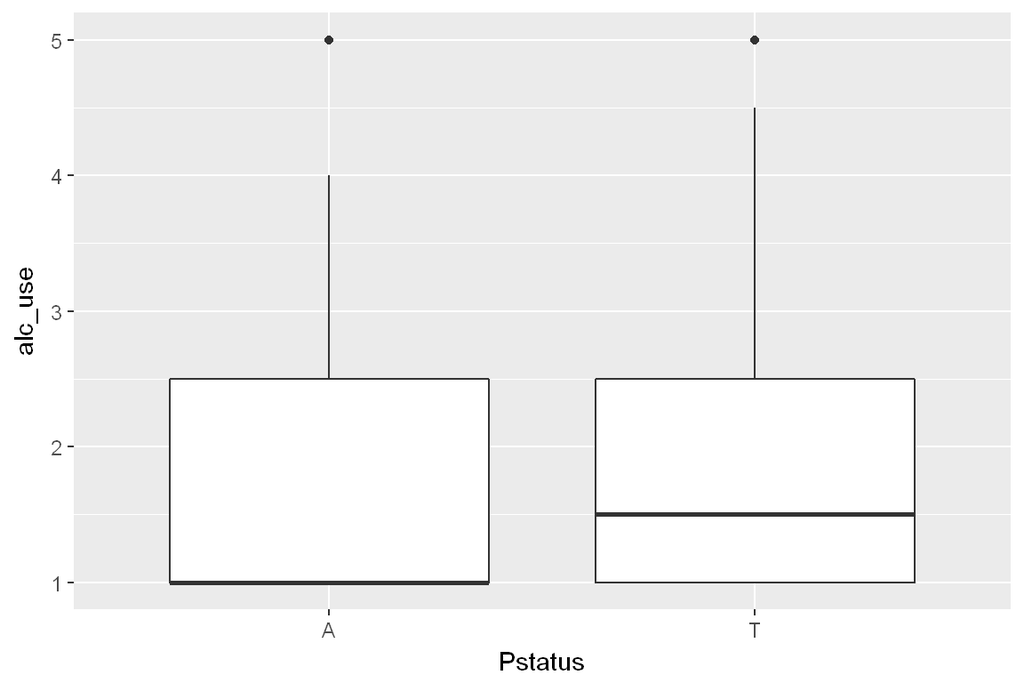

```r
g4 <- ggplot(alc, aes(x = Pstatus, y = alc_use))
g4 + geom_boxplot() + ylab("alc_use")
```

32% of students whose parents live apart are high alcohol users compared to 30% of students whose parents live together are high alcohol users. This indicates no large differences in high alcohol use depending on the parental cohabitation status. In addition, we can see in the boxplot that while the average alcohol consumption is slightly higher for the “together” group, the distributions are very similar in both groups, indicating no differences. The hypothesis is not supported.

## romantic vs high_use

```r
CrossTable(alc$romantic, alc$high_use)
```

```
##
##
##    Cell Contents
## |-------------------------|
## |                       N |
## | Chi-square contribution |
## |           N / Row Total |
## |           N / Col Total |
## |         N / Table Total |
## |-------------------------|
##
##
## Total Observations in Table:  382
##
##
##              | alc$high_use
## alc$romantic |     FALSE |      TRUE | Row Total |
## -------------|-----------|-----------|-----------|
##           no |       182 |        79 |       261 |
##              |     0.033 |     0.080 |           |
##              |     0.697 |     0.303 |     0.683 |
##              |     0.674 |     0.705 |           |
##              |     0.476 |     0.207 |           |
## -------------|-----------|-----------|-----------|
##          yes |        88 |        33 |       121 |
##              |     0.072 |     0.173 |           |
##              |     0.727 |     0.273 |     0.317 |
##              |     0.326 |     0.295 |           |
##              |     0.230 |     0.086 |           |
## -------------|-----------|-----------|-----------|
## Column Total |       270 |       112 |       382 |
##              |     0.707 |     0.293 |           |
## -------------|-----------|-----------|-----------|
##
##
```

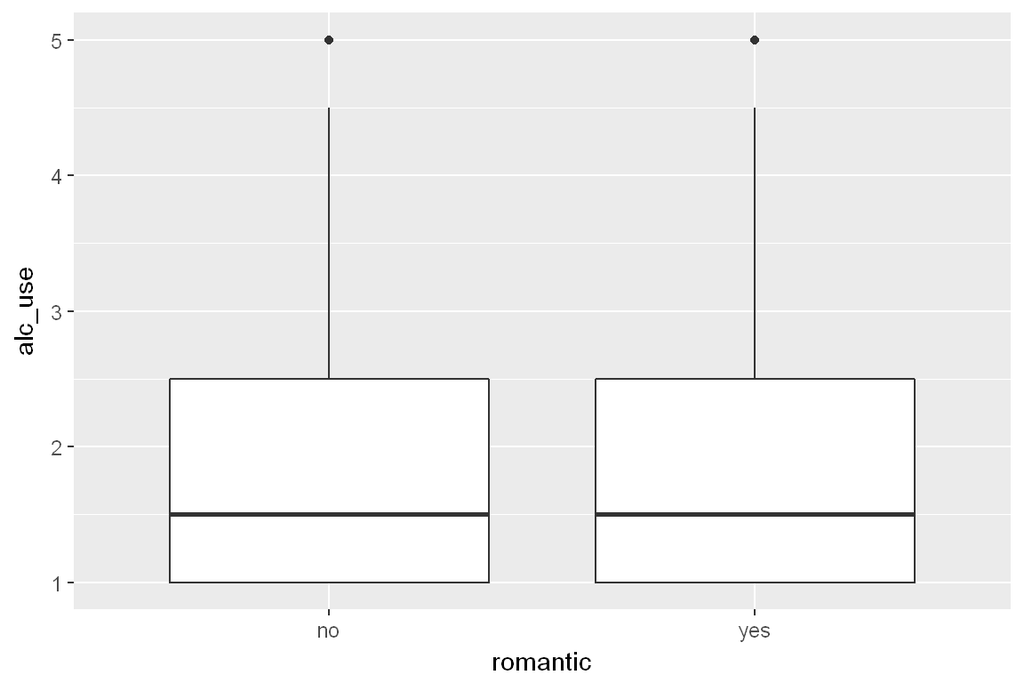

```r
g5 <- ggplot(alc, aes(x = romantic, y = alc_use))

g5 + geom_boxplot() + ylab("alc_use")
```

# Logistic regression

```r
m <- glm (high_use ~ sex + age + Pstatus + romantic, data = alc, family = "binomial")

summary (m)
```

```
##
## Call:
## glm(formula = high_use ~ sex + age + Pstatus + romantic, family = "binomial",
##     data = alc)
##
## Deviance Residuals:
##     Min       1Q   Median       3Q      Max
## -1.4023  -0.8664  -0.6634   1.2355   1.9918
##
## Coefficients:
##             Estimate Std. Error z value Pr(>|z|)
## (Intercept) -4.71264    1.66553  -2.830 0.004662 **
## sexM         0.88897    0.23408   3.798 0.000146 ***
## age          0.21692    0.09864   2.199 0.027874 *
## PstatusT    -0.21649    0.38236  -0.566 0.571257
## romanticyes -0.16035    0.25391  -0.632 0.527685
## ---
## Signif. codes:  0 '***' 0.001 '**' 0.01 '*' 0.05 '.' 0.1 ' ' 1
##
## (Dispersion parameter for binomial family taken to be 1)
##
##     Null deviance: 462.21  on 381  degrees of freedom
## Residual deviance: 442.18  on 377  degrees of freedom
## AIC: 452.18
##
## Number of Fisher Scoring iterations: 4
```

```r
coef(m)
```

```
## (Intercept)        sexM         age    PstatusT romanticyes
##  -4.7126355   0.8889660   0.2169175  -0.2164925  -0.1603532
```

The logistic regression model shows significant estimates for sex (0.88) and age (0.23) while Pstatus and romantic don’t have a signficant influence on high_use. This indicates that men are more likely to be high alcohol users than women and that higher age increases the chances to be a high alcohol user

## Odds-Ratios with Confidence Intervals

```r
OR <- coef(m)%>%exp

confint(m)
```

```
##                   2.5 %     97.5 %
## (Intercept) -8.03081816 -1.4826252
## sexM         0.43472494  1.3539681
## age          0.02498304  0.4128488
## PstatusT    -0.94914320  0.5619781
## romanticyes -0.66609321  0.3316545
```

```r
CI <- confint(m) %>% exp
cbind (OR, CI)
```

```
##                      OR       2.5 %    97.5 %
## (Intercept) 0.008981077 0.000325282 0.2270409
## sexM        2.432613009 1.544538157 3.8727624
## age         1.242241671 1.025297727 1.5111165
## PstatusT    0.805338579 0.387072524 1.7541389
## romanticyes 0.851842826 0.513711627 1.3932714
```

Here, I examine how well the model actually predicts high alcohol use.

```r
probabilities <- predict(m, type = "response")

alc <- mutate(alc, probability = probabilities)

alc <- mutate(alc, prediction = probability > 0.5)

table(high_use = alc$high_use, prediction = alc$prediction)
```

```
##         prediction
## high_use FALSE TRUE
##    FALSE   266    4
##    TRUE    108    4
```

Let’s take a closer look at the significant predictors from the model: sex and age

```r
m1 <- glm(high_use ~ sex + age, data = alc, family = "binomial")
probabilities <- predict(m1, type = "response")
alc <- mutate(alc, probability = probabilities)
alc <- mutate(alc, prediction = probability > 0.5)
table(high_use = alc$high_use, prediction = alc$prediction)
```

```
##         prediction
## high_use FALSE TRUE
##    FALSE   265    5
##    TRUE    109    3
```

We can see that this model is - in absolute numbers - worse than the one with more predictors (which is trivial) The number of correct “TRUE” predictions is now only 3 instead of 4. This plot illustrates the inaccuracy of the model prediction:

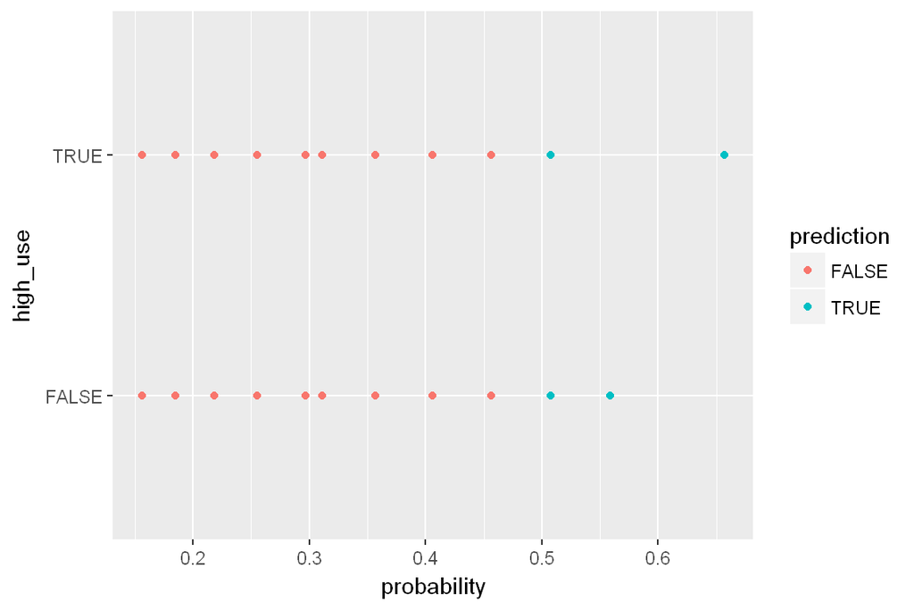

```r
g_m1 <- ggplot(alc, aes(x = probability, y = high_use, col = prediction))
g_m1 + geom_point()
```

## Loss function

```r
table(high_use = alc$high_use, prediction = alc$prediction) %>% prop.table() %>% addmargins()
```

```
##         prediction
## high_use       FALSE        TRUE         Sum
##    FALSE 0.693717277 0.013089005 0.706806283
##    TRUE  0.285340314 0.007853403 0.293193717
##    Sum   0.979057592 0.020942408 1.000000000
```

```r
loss_func <- function(class, prob) {
  n_wrong <- abs(class - prob) > 0.5
  mean(n_wrong)
}

loss_func(class = alc$high_use, prob = alc$probability)
```

```
## [1] 0.2984293
```

In this table and with the help of the loss function we can see that in total ~ 30% of all predictions were incorrect, mostly high users falsely predicted as non high users. Of the remaining 70% correctly classified cases, almost all are correctly classified as “FALSE”. The model is very conservative, avoiding false alarms. Almost 30% of all students are high users. If we had predicted everyone as non high user, the proportion of wrong predictions would have been very similar to what we obtained with the model. The model is therefore not very predictive.

## Cross-validation

```r
library(boot)
cv <- cv.glm(data = alc, cost = loss_func, glmfit = m1, K = 10)
cv$delta[1]
```

```
## [1] 0.2984293
```

## Is it possible to find a better model?

By throwing in more predictors, we will surely get a better prediction.

```r
m2 <- glm (high_use ~ age + sex + famsize + Medu + Fedu + studytime + failures + higher + paid + activities + famrel + freetime + goout, data = alc, family = "binomial")

probabilities <- predict(m2, type = "response")
alc <- mutate(alc, probability = probabilities)
alc <- mutate(alc, prediction = probability > 0.5)

table(high_use = alc$high_use, prediction = alc$prediction)
```

```
##         prediction
## high_use FALSE TRUE
##    FALSE   246   24
##    TRUE     60   52
```

```r
loss_func <- function(class, prob) {
  n_wrong <- abs(class - prob) > 0.5
  mean(n_wrong)
}

loss_func(class = alc$high_use, prob = alc$probability)
```

```
## [1] 0.2198953
```

```r
library(boot)
cv2 <- cv.glm(data = alc, cost = loss_func, glmfit = m2, K = 10)
cv2$delta[1]
```

```
## [1] 0.2408377
```

By adding all these variables, we decreased the loss function to .22 and the average amount of wrong predictions in the 10-fold cross-validation to 0.24, a value better than in the Datacamp exercise.

```r
summary(m2)
```

```
##
## Call:
## glm(formula = high_use ~ age + sex + famsize + Medu + Fedu +
##     studytime + failures + higher + paid + activities + famrel +
##     freetime + goout, family = "binomial", data = alc)
##
## Deviance Residuals:
##     Min       1Q   Median       3Q      Max
## -1.7068  -0.7632  -0.4723   0.7604   2.6476
##
## Coefficients:
##               Estimate Std. Error z value Pr(>|z|)
## (Intercept)   -3.62654    2.24424  -1.616  0.10611
## age            0.11001    0.11611   0.947  0.34341
## sexM           0.83375    0.28426   2.933  0.00336 **
## famsizeLE3     0.30353    0.28418   1.068  0.28548
## Medu          -0.14031    0.16074  -0.873  0.38272
## Fedu           0.14379    0.16283   0.883  0.37721
## studytime     -0.42563    0.18207  -2.338  0.01940 *
## failures       0.21405    0.19064   1.123  0.26152
## higheryes     -0.01489    0.62990  -0.024  0.98115
## paidyes        0.56769    0.27259   2.083  0.03729 *
## activitiesyes -0.38334    0.26912  -1.424  0.15433
## famrel        -0.44718    0.14437  -3.097  0.00195 **
## freetime       0.12135    0.14283   0.850  0.39553
## goout          0.74815    0.12947   5.779 7.53e-09 ***
## ---
## Signif. codes:  0 '***' 0.001 '**' 0.01 '*' 0.05 '.' 0.1 ' ' 1
##
## (Dispersion parameter for binomial family taken to be 1)
##
##     Null deviance: 462.21  on 381  degrees of freedom
## Residual deviance: 368.47  on 368  degrees of freedom
## AIC: 396.47
##
## Number of Fisher Scoring iterations: 5
```

Let’s eliminate “higher” first since it has the lowest z value. So here’s the model without “higher”.

```
##
## Call:
## glm(formula = high_use ~ age + sex + famsize + Medu + Fedu +
##     studytime + failures + paid + activities + famrel + freetime +
##     goout, family = "binomial", data = alc)
##
## Deviance Residuals:
##     Min       1Q   Median       3Q      Max
## -1.7028  -0.7636  -0.4724   0.7597   2.6478
##
## Coefficients:
##               Estimate Std. Error z value Pr(>|z|)
## (Intercept)    -3.6473     2.0648  -1.766  0.07732 .
## age             0.1105     0.1143   0.966  0.33387
## sexM            0.8346     0.2817   2.962  0.00305 **
## famsizeLE3      0.3035     0.2842   1.068  0.28553
## Medu           -0.1404     0.1606  -0.874  0.38195
## Fedu            0.1437     0.1628   0.883  0.37736
## studytime      -0.4259     0.1817  -2.344  0.01910 *
## failures        0.2151     0.1854   1.160  0.24594
## paidyes         0.5670     0.2709   2.093  0.03635 *
## activitiesyes  -0.3839     0.2679  -1.433  0.15186
## famrel         -0.4473     0.1443  -3.099  0.00194 **
## freetime        0.1214     0.1428   0.850  0.39526
## goout           0.7481     0.1295   5.778 7.55e-09 ***
## ---
## Signif. codes:  0 '***' 0.001 '**' 0.01 '*' 0.05 '.' 0.1 ' ' 1
##
## (Dispersion parameter for binomial family taken to be 1)
##
##     Null deviance: 462.21  on 381  degrees of freedom
## Residual deviance: 368.47  on 369  degrees of freedom
## AIC: 394.47
##
## Number of Fisher Scoring iterations: 5
```

```
##         prediction
## high_use FALSE TRUE
##    FALSE   246   24
##    TRUE     60   52
```

```
## [1] 0.2198953
```

```
## [1] 0.2329843
```

Next-lowest predictor is “freetime”. Let’s try eliminating this as well.

```
##
## Call:
## glm(formula = high_use ~ age + sex + famsize + Medu + Fedu +
##     studytime + failures + paid + activities + famrel + goout,
##     family = "binomial", data = alc)
##
## Deviance Residuals:
##     Min       1Q   Median       3Q      Max
## -1.6934  -0.7628  -0.4671   0.7552   2.6936
##
## Coefficients:
##               Estimate Std. Error z value Pr(>|z|)
## (Intercept)    -3.3461     2.0364  -1.643  0.10036
## age             0.1062     0.1143   0.930  0.35251
## sexM            0.8626     0.2796   3.085  0.00203 **
## famsizeLE3      0.3029     0.2840   1.067  0.28615
## Medu           -0.1328     0.1603  -0.829  0.40736
## Fedu            0.1340     0.1624   0.825  0.40930
## studytime      -0.4293     0.1814  -2.366  0.01797 *
## failures        0.2232     0.1856   1.203  0.22915
## paidyes         0.5575     0.2702   2.063  0.03911 *
## activitiesyes  -0.3683     0.2668  -1.380  0.16753
## famrel         -0.4308     0.1425  -3.022  0.00251 **
## goout           0.7768     0.1258   6.176 6.57e-10 ***
## ---
## Signif. codes:  0 '***' 0.001 '**' 0.01 '*' 0.05 '.' 0.1 ' ' 1
##
## (Dispersion parameter for binomial family taken to be 1)
##
##     Null deviance: 462.21  on 381  degrees of freedom
## Residual deviance: 369.20  on 370  degrees of freedom
## AIC: 393.2
##
## Number of Fisher Scoring iterations: 4
```

```
##         prediction
## high_use FALSE TRUE
##    FALSE   245   25
##    TRUE     58   54
```

```
## [1] 0.2172775
```

```
## [1] 0.2303665
```

```
##
## Call:
## glm(formula = high_use ~ age + sex + famsize + Fedu + studytime +
##     failures + paid + activities + famrel + goout, family = "binomial",
##     data = alc)
##
## Deviance Residuals:
##     Min       1Q   Median       3Q      Max
## -1.7204  -0.7503  -0.4694   0.7639   2.6275
##
## Coefficients:
##               Estimate Std. Error z value Pr(>|z|)
## (Intercept)   -3.51102    2.02791  -1.731  0.08339 .
## age            0.11023    0.11419   0.965  0.33437
## sexM           0.84644    0.27830   3.042  0.00235 **
## famsizeLE3     0.29734    0.28377   1.048  0.29473
## Fedu           0.04791    0.12395   0.387  0.69910
## studytime     -0.43263    0.18036  -2.399  0.01645 *
## failures       0.23230    0.18569   1.251  0.21094
## paidyes        0.53006    0.26784   1.979  0.04781 *
## activitiesyes -0.37629    0.26622  -1.413  0.15753
## famrel        -0.42843    0.14240  -3.009  0.00263 **
## goout          0.76844    0.12517   6.139 8.28e-10 ***
## ---
## Signif. codes:  0 '***' 0.001 '**' 0.01 '*' 0.05 '.' 0.1 ' ' 1
##
## (Dispersion parameter for binomial family taken to be 1)
##
##     Null deviance: 462.21  on 381  degrees of freedom
## Residual deviance: 369.89  on 371  degrees of freedom
## AIC: 391.89
##
## Number of Fisher Scoring iterations: 4
```

```
##         prediction
## high_use FALSE TRUE
##    FALSE   245   25
##    TRUE     61   51
```

```
## [1] 0.2251309
```

```
## [1] 0.2382199
```

The next-lowest value is “Fedu”, so here it goes.

```
##
## Call:
## glm(formula = high_use ~ age + sex + famsize + studytime + failures +
##     paid + activities + famrel + goout, family = "binomial",
##     data = alc)
##
## Deviance Residuals:
##     Min       1Q   Median       3Q      Max
## -1.7337  -0.7559  -0.4675   0.7715   2.6155
##
## Coefficients:
##               Estimate Std. Error z value Pr(>|z|)
## (Intercept)    -3.3286     1.9725  -1.688  0.09150 .
## age             0.1066     0.1138   0.937  0.34877
## sexM            0.8515     0.2778   3.065  0.00218 **
## famsizeLE3      0.2882     0.2828   1.019  0.30816
## studytime      -0.4335     0.1799  -2.410  0.01596 *
## failures        0.2144     0.1798   1.192  0.23318
## paidyes         0.5326     0.2676   1.990  0.04656 *
## activitiesyes  -0.3661     0.2648  -1.383  0.16680
## famrel         -0.4314     0.1422  -3.034  0.00241 **
## goout           0.7725     0.1247   6.193 5.91e-10 ***
## ---
## Signif. codes:  0 '***' 0.001 '**' 0.01 '*' 0.05 '.' 0.1 ' ' 1
##
## (Dispersion parameter for binomial family taken to be 1)
##
##     Null deviance: 462.21  on 381  degrees of freedom
## Residual deviance: 370.03  on 372  degrees of freedom
## AIC: 390.03
##
## Number of Fisher Scoring iterations: 4
```

```
##         prediction
## high_use FALSE TRUE
##    FALSE   244   26
##    TRUE     60   52
```

```
## [1] 0.2251309
```

```
## [1] 0.2513089
```

```
##
## Call:
## glm(formula = high_use ~ age + sex + studytime + failures + paid +
##     activities + famrel + goout, family = "binomial", data = alc)
##
## Deviance Residuals:
##     Min       1Q   Median       3Q      Max
## -1.7680  -0.7666  -0.4786   0.7588   2.6886
##
## Coefficients:
##               Estimate Std. Error z value Pr(>|z|)
## (Intercept)    -3.1951     1.9677  -1.624  0.10443
## age             0.1061     0.1139   0.931  0.35176
## sexM            0.8759     0.2767   3.166  0.00155 **
## studytime      -0.4443     0.1792  -2.480  0.01315 *
## failures        0.2043     0.1793   1.139  0.25454
## paidyes         0.5330     0.2674   1.993  0.04621 *
## activitiesyes  -0.3773     0.2642  -1.428  0.15325
## famrel         -0.4380     0.1414  -3.098  0.00195 **
## goout           0.7729     0.1246   6.201 5.62e-10 ***
## ---
## Signif. codes:  0 '***' 0.001 '**' 0.01 '*' 0.05 '.' 0.1 ' ' 1
##
## (Dispersion parameter for binomial family taken to be 1)
##
##     Null deviance: 462.21  on 381  degrees of freedom
## Residual deviance: 371.06  on 373  degrees of freedom
## AIC: 389.06
##
## Number of Fisher Scoring iterations: 4
```

```
##         prediction
## high_use FALSE TRUE
##    FALSE   247   23
##    TRUE     61   51
```

```
## [1] 0.2198953
```

```
## [1] 0.2277487
```

Training error: 0.22, testing error: 0.23. No major changes. Next to go is “age”.

```
##
## Call:
## glm(formula = high_use ~ sex + studytime + failures + paid +
##     activities + famrel + goout, family = "binomial", data = alc)
##
## Deviance Residuals:
##     Min       1Q   Median       3Q      Max
## -1.7906  -0.7366  -0.4785   0.7568   2.6290
##
## Coefficients:
##               Estimate Std. Error z value Pr(>|z|)
## (Intercept)    -1.5033     0.7441  -2.020  0.04335 *
## sexM            0.8778     0.2759   3.182  0.00146 **
## studytime      -0.4389     0.1780  -2.466  0.01367 *
## failures        0.2293     0.1764   1.300  0.19351
## paidyes         0.5340     0.2668   2.001  0.04537 *
## activitiesyes  -0.3828     0.2636  -1.452  0.14640
## famrel         -0.4333     0.1410  -3.072  0.00212 **
## goout           0.7843     0.1241   6.318 2.65e-10 ***
## ---
## Signif. codes:  0 '***' 0.001 '**' 0.01 '*' 0.05 '.' 0.1 ' ' 1
##
## (Dispersion parameter for binomial family taken to be 1)
##
##     Null deviance: 462.21  on 381  degrees of freedom
## Residual deviance: 371.93  on 374  degrees of freedom
## AIC: 387.93
##
## Number of Fisher Scoring iterations: 4
```

```
##         prediction
## high_use FALSE TRUE
##    FALSE   245   25
##    TRUE     60   52
```

```
## [1] 0.2225131
```

```
## [1] 0.2408377
```

```
##
## Call:
## glm(formula = high_use ~ sex + studytime + failures + paid +
##     famrel + goout, family = "binomial", data = alc)
##
## Deviance Residuals:
##     Min       1Q   Median       3Q      Max
## -1.7059  -0.7607  -0.4839   0.7563   2.7108
##
## Coefficients:
##             Estimate Std. Error z value Pr(>|z|)
## (Intercept)  -1.5512     0.7396  -2.097  0.03596 *
## sexM          0.8079     0.2701   2.991  0.00278 **
## studytime    -0.4752     0.1773  -2.681  0.00735 **
## failures      0.2419     0.1747   1.385  0.16619
## paidyes       0.5434     0.2664   2.040  0.04139 *
## famrel       -0.4347     0.1400  -3.105  0.00190 **
## goout         0.7712     0.1228   6.282 3.34e-10 ***
## ---
## Signif. codes:  0 '***' 0.001 '**' 0.01 '*' 0.05 '.' 0.1 ' ' 1
##
## (Dispersion parameter for binomial family taken to be 1)
##
##     Null deviance: 462.21  on 381  degrees of freedom
## Residual deviance: 374.06  on 375  degrees of freedom
## AIC: 388.06
##
## Number of Fisher Scoring iterations: 4
```

```
##         prediction
## high_use FALSE TRUE
##    FALSE   246   24
##    TRUE     65   47
```

```
## [1] 0.2329843
```

```
## [1] 0.2408377
```

Training error: 0.23, testing error: 0.24. Oh well… Next variable to go: “failures”.

```
##
## Call:
## glm(formula = high_use ~ sex + studytime + paid + famrel + goout,
##     family = "binomial", data = alc)
##
## Deviance Residuals:
##     Min       1Q   Median       3Q      Max
## -1.6381  -0.7833  -0.4743   0.7631   2.7132
##
## Coefficients:
##             Estimate Std. Error z value Pr(>|z|)
## (Intercept)  -1.4081     0.7315  -1.925  0.05425 .
## sexM          0.8012     0.2691   2.978  0.00290 **
## studytime    -0.5167     0.1747  -2.957  0.00310 **
## paidyes       0.4704     0.2602   1.808  0.07061 .
## famrel       -0.4433     0.1393  -3.183  0.00146 **
## goout         0.7963     0.1224   6.508 7.62e-11 ***
## ---
## Signif. codes:  0 '***' 0.001 '**' 0.01 '*' 0.05 '.' 0.1 ' ' 1
##
## (Dispersion parameter for binomial family taken to be 1)
##
##     Null deviance: 462.21  on 381  degrees of freedom
## Residual deviance: 375.97  on 376  degrees of freedom
## AIC: 387.97
##
## Number of Fisher Scoring iterations: 4
```

```
##         prediction
## high_use FALSE TRUE
##    FALSE   249   21
##    TRUE     65   47
```

```
## [1] 0.2251309
```

```
## [1] 0.2303665
```

```
##
## Call:
## glm(formula = high_use ~ sex + studytime + famrel + goout, family = "binomial",
##     data = alc)
##
## Deviance Residuals:
##     Min       1Q   Median       3Q      Max
## -1.5928  -0.7494  -0.4919   0.8250   2.7080
##
## Coefficients:
##             Estimate Std. Error z value Pr(>|z|)
## (Intercept)  -1.2112     0.7142  -1.696  0.08991 .
## sexM          0.7593     0.2655   2.860  0.00424 **
## studytime    -0.4752     0.1703  -2.790  0.00527 **
## famrel       -0.4496     0.1379  -3.260  0.00111 **
## goout         0.7947     0.1218   6.523 6.89e-11 ***
## ---
## Signif. codes:  0 '***' 0.001 '**' 0.01 '*' 0.05 '.' 0.1 ' ' 1
##
## (Dispersion parameter for binomial family taken to be 1)
##
##     Null deviance: 462.21  on 381  degrees of freedom
## Residual deviance: 379.27  on 377  degrees of freedom
## AIC: 389.27
##
## Number of Fisher Scoring iterations: 4
```

```
##         prediction
## high_use FALSE TRUE
##    FALSE   244   26
##    TRUE     66   46
```

```
## [1] 0.2408377
```

```
## [1] 0.2434555
```

```
##
## Call:
## glm(formula = high_use ~ sex + famrel + goout, family = "binomial",
##     data = alc)
##
## Deviance Residuals:
##     Min       1Q   Median       3Q      Max
## -1.5782  -0.7773  -0.5086   0.8240   2.5739
##
## Coefficients:
##             Estimate Std. Error z value Pr(>|z|)
## (Intercept)  -2.2055     0.6284  -3.510 0.000448 ***
## sexM          0.9588     0.2541   3.773 0.000162 ***
## famrel       -0.4689     0.1381  -3.397 0.000682 ***
## goout         0.8057     0.1217   6.620  3.6e-11 ***
## ---
## Signif. codes:  0 '***' 0.001 '**' 0.01 '*' 0.05 '.' 0.1 ' ' 1
##
## (Dispersion parameter for binomial family taken to be 1)
##
##     Null deviance: 462.21  on 381  degrees of freedom
## Residual deviance: 387.54  on 378  degrees of freedom
## AIC: 395.54
##
## Number of Fisher Scoring iterations: 4
```

```
##         prediction
## high_use FALSE TRUE
##    FALSE   251   19
##    TRUE     62   50
```

```
## [1] 0.2120419
```

```
## [1] 0.2303665
```

```
##
## Call:
## glm(formula = high_use ~ sex + goout, family = "binomial", data = alc)
##
## Deviance Residuals:
##     Min       1Q   Median       3Q      Max
## -1.5434  -0.8571  -0.6157   0.8512   2.4985
##
## Coefficients:
##             Estimate Std. Error z value Pr(>|z|)
## (Intercept)  -3.8309     0.4529  -8.458  < 2e-16 ***
## sexM          0.8865     0.2480   3.575 0.000351 ***
## goout         0.7546     0.1175   6.425 1.32e-10 ***
## ---
## Signif. codes:  0 '***' 0.001 '**' 0.01 '*' 0.05 '.' 0.1 ' ' 1
##
## (Dispersion parameter for binomial family taken to be 1)
##
##     Null deviance: 462.21  on 381  degrees of freedom
## Residual deviance: 399.34  on 379  degrees of freedom
## AIC: 405.34
##
## Number of Fisher Scoring iterations: 4
```

```
##         prediction
## high_use FALSE TRUE
##    FALSE   251   19
##    TRUE     62   50
```

```
## [1] 0.2120419
```

```
## [1] 0.2146597
```

```
##
## Call:
## glm(formula = high_use ~ goout, family = "binomial", data = alc)
##
## Deviance Residuals:
##     Min       1Q   Median       3Q      Max
## -1.3531  -0.7573  -0.5391   1.0113   2.3150
##
## Coefficients:
##             Estimate Std. Error z value Pr(>|z|)
## (Intercept)  -3.3617     0.4154  -8.092 5.87e-16 ***
## goout         0.7532     0.1152   6.539 6.21e-11 ***
## ---
## Signif. codes:  0 '***' 0.001 '**' 0.01 '*' 0.05 '.' 0.1 ' ' 1
##
## (Dispersion parameter for binomial family taken to be 1)
##
##     Null deviance: 462.21  on 381  degrees of freedom
## Residual deviance: 412.52  on 380  degrees of freedom
## AIC: 416.52
##
## Number of Fisher Scoring iterations: 4
```

```
##         prediction
## high_use FALSE TRUE
##    FALSE   248   22
##    TRUE     80   32
```

```
## [1] 0.2670157
```

```
## [1] 0.2670157
```

Now here’s some change, finally! Training error: 0.27, testing error: 0.27. So when we don’t take “sex” into account, our predictions get much worse.

And here’s a graph on the testing error depending on the numbers of predictors. So here we see that only the removal of the last one made a large change for the testing error. Or put the other way around: The second predictor makes the prediction quite a lot better while adding the others (even though they were significant in the model) did not make the predictions considerably better.

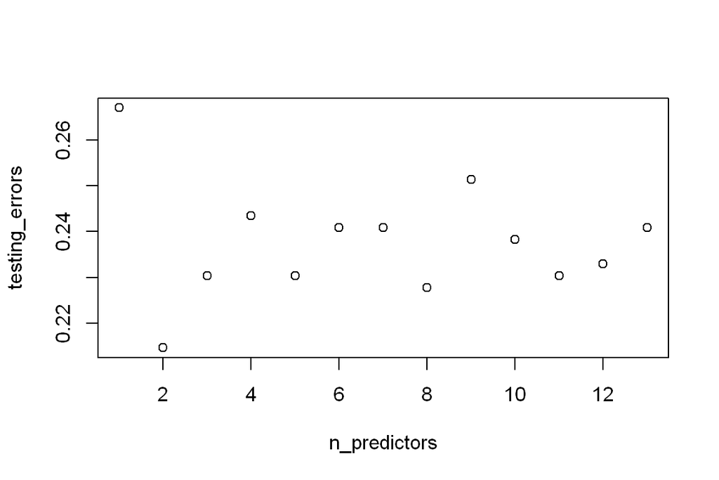

```r
testing_errors <- c(cv2$delta [1], cv3$delta [1], cv4$delta [1], cv5$delta [1], cv6$delta [1], cv7$delta [1], cv8$delta [1], cv9$delta [1], cv10$delta [1], cv11$delta [1], cv12$delta [1], cv13$delta [1], cv14$delta [1])

n_predictors <- c(13:1)

plot(n_predictors, testing_errors)
```

P.S.: If you have an idea how any of this could be done easier, please let me know (that’s one reason I included almost all the code and outputs, so you can have a look).

# Week 4 - Clustering and Classification

## Exploring the dataset

The “Boston” dataset consists of 14 variables with 506 observations for each variable. The variables cover different properties of housing areas.

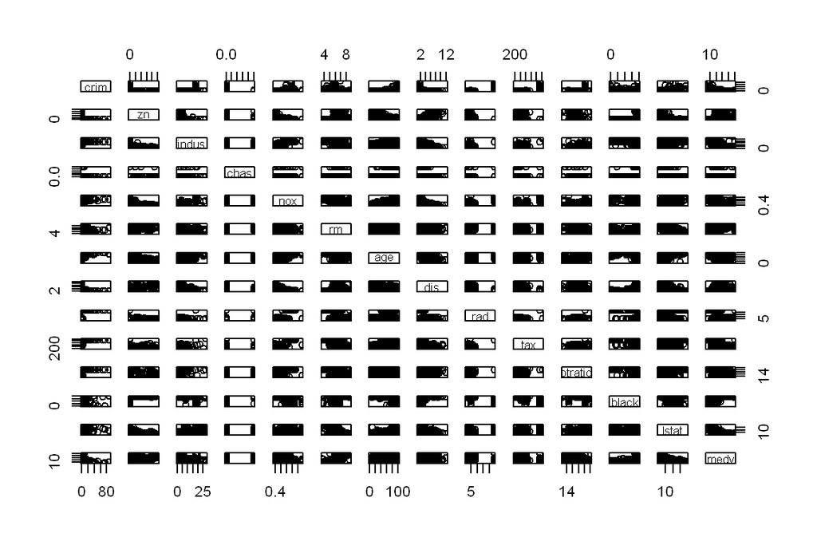

```r
pairs(Boston)
```

```r
summary(Boston)
```

```
##       crim                zn             indus            chas
##  Min.   : 0.00632   Min.   :  0.00   Min.   : 0.46   Min.   :0.00000
##  1st Qu.: 0.08204   1st Qu.:  0.00   1st Qu.: 5.19   1st Qu.:0.00000
##  Median : 0.25651   Median :  0.00   Median : 9.69   Median :0.00000
##  Mean   : 3.61352   Mean   : 11.36   Mean   :11.14   Mean   :0.06917
##  3rd Qu.: 3.67708   3rd Qu.: 12.50   3rd Qu.:18.10   3rd Qu.:0.00000
##  Max.   :88.97620   Max.   :100.00   Max.   :27.74   Max.   :1.00000
##       nox               rm             age              dis
##  Min.   :0.3850   Min.   :3.561   Min.   :  2.90   Min.   : 1.130
##  1st Qu.:0.4490   1st Qu.:5.886   1st Qu.: 45.02   1st Qu.: 2.100
##  Median :0.5380   Median :6.208   Median : 77.50   Median : 3.207
##  Mean   :0.5547   Mean   :6.285   Mean   : 68.57   Mean   : 3.795
##  3rd Qu.:0.6240   3rd Qu.:6.623   3rd Qu.: 94.08   3rd Qu.: 5.188
##  Max.   :0.8710   Max.   :8.780   Max.   :100.00   Max.   :12.127
##       rad              tax           ptratio          black
##  Min.   : 1.000   Min.   :187.0   Min.   :12.60   Min.   :  0.32
##  1st Qu.: 4.000   1st Qu.:279.0   1st Qu.:17.40   1st Qu.:375.38
##  Median : 5.000   Median :330.0   Median :19.05   Median :391.44
##  Mean   : 9.549   Mean   :408.2   Mean   :18.46   Mean   :356.67
##  3rd Qu.:24.000   3rd Qu.:666.0   3rd Qu.:20.20   3rd Qu.:396.23
##  Max.   :24.000   Max.   :711.0   Max.   :22.00   Max.   :396.90
##      lstat            medv
##  Min.   : 1.73   Min.   : 5.00
##  1st Qu.: 6.95   1st Qu.:17.02
##  Median :11.36   Median :21.20
##  Mean   :12.65   Mean   :22.53
##  3rd Qu.:16.95   3rd Qu.:25.00
##  Max.   :37.97   Max.   :50.00
```

```r
cor_matrix<-cor(Boston) %>% round (digits = 2)
cor_matrix
```

```
##          crim    zn indus  chas   nox    rm   age   dis   rad   tax
## crim     1.00 -0.20  0.41 -0.06  0.42 -0.22  0.35 -0.38  0.63  0.58
## zn      -0.20  1.00 -0.53 -0.04 -0.52  0.31 -0.57  0.66 -0.31 -0.31
## indus    0.41 -0.53  1.00  0.06  0.76 -0.39  0.64 -0.71  0.60  0.72
## chas    -0.06 -0.04  0.06  1.00  0.09  0.09  0.09 -0.10 -0.01 -0.04
## nox      0.42 -0.52  0.76  0.09  1.00 -0.30  0.73 -0.77  0.61  0.67
## rm      -0.22  0.31 -0.39  0.09 -0.30  1.00 -0.24  0.21 -0.21 -0.29
## age      0.35 -0.57  0.64  0.09  0.73 -0.24  1.00 -0.75  0.46  0.51
## dis     -0.38  0.66 -0.71 -0.10 -0.77  0.21 -0.75  1.00 -0.49 -0.53
## rad      0.63 -0.31  0.60 -0.01  0.61 -0.21  0.46 -0.49  1.00  0.91
## tax      0.58 -0.31  0.72 -0.04  0.67 -0.29  0.51 -0.53  0.91  1.00
## ptratio  0.29 -0.39  0.38 -0.12  0.19 -0.36  0.26 -0.23  0.46  0.46
## black   -0.39  0.18 -0.36  0.05 -0.38  0.13 -0.27  0.29 -0.44 -0.44
## lstat    0.46 -0.41  0.60 -0.05  0.59 -0.61  0.60 -0.50  0.49  0.54
## medv    -0.39  0.36 -0.48  0.18 -0.43  0.70 -0.38  0.25 -0.38 -0.47
##         ptratio black lstat  medv
## crim       0.29 -0.39  0.46 -0.39
## zn        -0.39  0.18 -0.41  0.36
## indus      0.38 -0.36  0.60 -0.48
## chas      -0.12  0.05 -0.05  0.18
## nox        0.19 -0.38  0.59 -0.43
## rm        -0.36  0.13 -0.61  0.70
## age        0.26 -0.27  0.60 -0.38
## dis       -0.23  0.29 -0.50  0.25
## rad        0.46 -0.44  0.49 -0.38
## tax        0.46 -0.44  0.54 -0.47
## ptratio    1.00 -0.18  0.37 -0.51
## black     -0.18  1.00 -0.37  0.33
## lstat      0.37 -0.37  1.00 -0.74
## medv      -0.51  0.33 -0.74  1.00
```

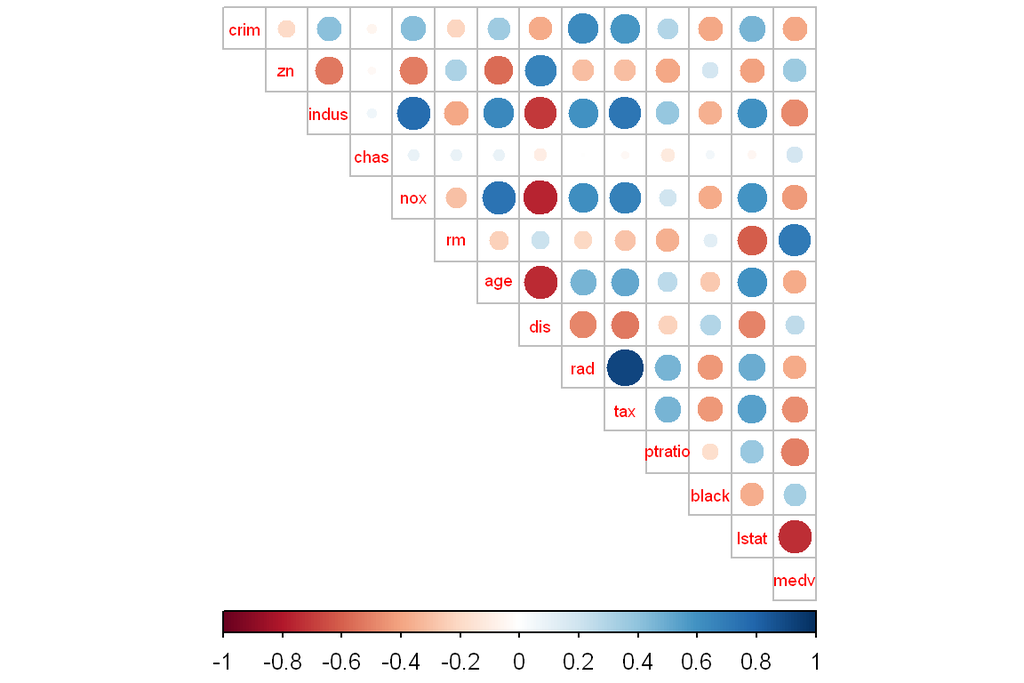

```r
corrplot(cor_matrix, method="circle", type = "upper", cl.pos = "b", tl.pos = "d", tl.cex = 0.6)
```

In the plot of the correlations, we can see that *dis*, the weighted mean of distances to five Boston employment centres, is strongly negatively related to *nox*, the nitrogen oxides concentration (parts per 10 million) and *indus*, the proportion of non-retail business acres per town. So the farther a place is from employment centres, the less polluted is the air and the lower the proportion of non-retail business. Also, *dis* and *age* are highly negatively correlated: the higher the proportion of owner-occupied units built prior to 1940, the smaller the distance to an emplyment center. In addition, we find a strong positive correlation between *rad* and *tax*, indicating that the more accesible the area in relation to radial highways, the higher the full-value property-tax rate. More correlations can be seen in the correlation matrix.

## Standardizing the data

```r
boston_scaled <- scale (Boston)
summary(boston_scaled)
```

```
##       crim                 zn               indus
##  Min.   :-0.419367   Min.   :-0.48724   Min.   :-1.5563
##  1st Qu.:-0.410563   1st Qu.:-0.48724   1st Qu.:-0.8668
##  Median :-0.390280   Median :-0.48724   Median :-0.2109
##  Mean   : 0.000000   Mean   : 0.00000   Mean   : 0.0000
##  3rd Qu.: 0.007389   3rd Qu.: 0.04872   3rd Qu.: 1.0150
##  Max.   : 9.924110   Max.   : 3.80047   Max.   : 2.4202
##       chas              nox                rm               age
##  Min.   :-0.2723   Min.   :-1.4644   Min.   :-3.8764   Min.   :-2.3331
##  1st Qu.:-0.2723   1st Qu.:-0.9121   1st Qu.:-0.5681   1st Qu.:-0.8366
##  Median :-0.2723   Median :-0.1441   Median :-0.1084   Median : 0.3171
##  Mean   : 0.0000   Mean   : 0.0000   Mean   : 0.0000   Mean   : 0.0000
##  3rd Qu.:-0.2723   3rd Qu.: 0.5981   3rd Qu.: 0.4823   3rd Qu.: 0.9059
##  Max.   : 3.6648   Max.   : 2.7296   Max.   : 3.5515   Max.   : 1.1164
##       dis               rad               tax             ptratio
##  Min.   :-1.2658   Min.   :-0.9819   Min.   :-1.3127   Min.   :-2.7047
##  1st Qu.:-0.8049   1st Qu.:-0.6373   1st Qu.:-0.7668   1st Qu.:-0.4876
##  Median :-0.2790   Median :-0.5225   Median :-0.4642   Median : 0.2746
##  Mean   : 0.0000   Mean   : 0.0000   Mean   : 0.0000   Mean   : 0.0000
##  3rd Qu.: 0.6617   3rd Qu.: 1.6596   3rd Qu.: 1.5294   3rd Qu.: 0.8058
##  Max.   : 3.9566   Max.   : 1.6596   Max.   : 1.7964   Max.   : 1.6372
##      black             lstat              medv
##  Min.   :-3.9033   Min.   :-1.5296   Min.   :-1.9063
##  1st Qu.: 0.2049   1st Qu.:-0.7986   1st Qu.:-0.5989
##  Median : 0.3808   Median :-0.1811   Median :-0.1449
##  Mean   : 0.0000   Mean   : 0.0000   Mean   : 0.0000
##  3rd Qu.: 0.4332   3rd Qu.: 0.6024   3rd Qu.: 0.2683
##  Max.   : 0.4406   Max.   : 3.5453   Max.   : 2.9865
```

```r
boston_scaled <- as.data.frame(boston_scaled)
bins <- quantile (boston_scaled$crim)
bins
```

```
##           0%          25%          50%          75%         100%
## -0.419366929 -0.410563278 -0.390280295  0.007389247  9.924109610
```

```r
crime <- cut(boston_scaled$crim, breaks = bins, label = c("low", "med_low", "med_high", "high"), include.lowest = TRUE)
boston_scaled <- dplyr::select(boston_scaled, -crim)
boston_scaled <- data.frame(boston_scaled, crime)
```

## Dividing the dataset into training and test sets

```r
n <- nrow(boston_scaled)
ind <- sample(n,  size = n * 0.8)
train <- boston_scaled[ind,]
test <- boston_scaled[-ind,]
correct_classes <- test$crime
test <- dplyr::select(test, -crime)
```

## Linear Discriminant Analysis

```r
lda.fit <- lda (crime ~ ., data = train)
lda.fit
```

```
## Call:
## lda(crime ~ ., data = train)
##
## Prior probabilities of groups:
##       low   med_low  med_high      high
## 0.2524752 0.2574257 0.2425743 0.2475248
##
## Group means:
##                   zn      indus         chas        nox         rm
## low       0.93905515 -0.9245386 -0.156532002 -0.8794768  0.4049188
## med_low  -0.09907842 -0.3141027 -0.007331936 -0.5894301 -0.1030348
## med_high -0.38048487  0.1259019  0.169590347  0.3013280  0.1603165
## high     -0.48724019  1.0171519 -0.075474056  1.0729844 -0.3998542
##                 age        dis        rad        tax     ptratio
## low      -0.8860944  0.8987939 -0.6801171 -0.7373828 -0.39426988
## med_low  -0.3760877  0.3748989 -0.5423617 -0.4610183 -0.07273009
## med_high  0.3533908 -0.3336873 -0.4006063 -0.3080071 -0.27310058
## high      0.8369113 -0.8458508  1.6377820  1.5138081  0.78037363
##                black      lstat       medv
## low       0.37675044 -0.7497683  0.4897681
## med_low   0.31816504 -0.1690771  0.0182835
## med_high  0.08520663 -0.0220201  0.2227686
## high     -0.67717754  0.8142818 -0.6400717
##
## Coefficients of linear discriminants:
##                 LD1          LD2        LD3
## zn       0.07930861  0.817065164 -0.9542854
## indus    0.04098604 -0.393460273  0.2574816
## chas    -0.10686249 -0.067734099  0.1114466
## nox      0.44721017 -0.588303755 -1.5276165
## rm      -0.09158103 -0.137270228 -0.1274611
## age      0.25512083 -0.270786007 -0.1632290
## dis     -0.01564075 -0.292823422  0.1306014
## rad      3.17372080  0.933451685  0.0559119
## tax     -0.02427958  0.006682453  0.6677166
## ptratio  0.08233443  0.072760054 -0.3312405
## black   -0.10437190  0.031857471  0.1921260
## lstat    0.18508189 -0.289250306  0.3989796
## medv     0.16131649 -0.402082407 -0.1949328
##
## Proportion of trace:
##    LD1    LD2    LD3
## 0.9488 0.0375 0.0137
```

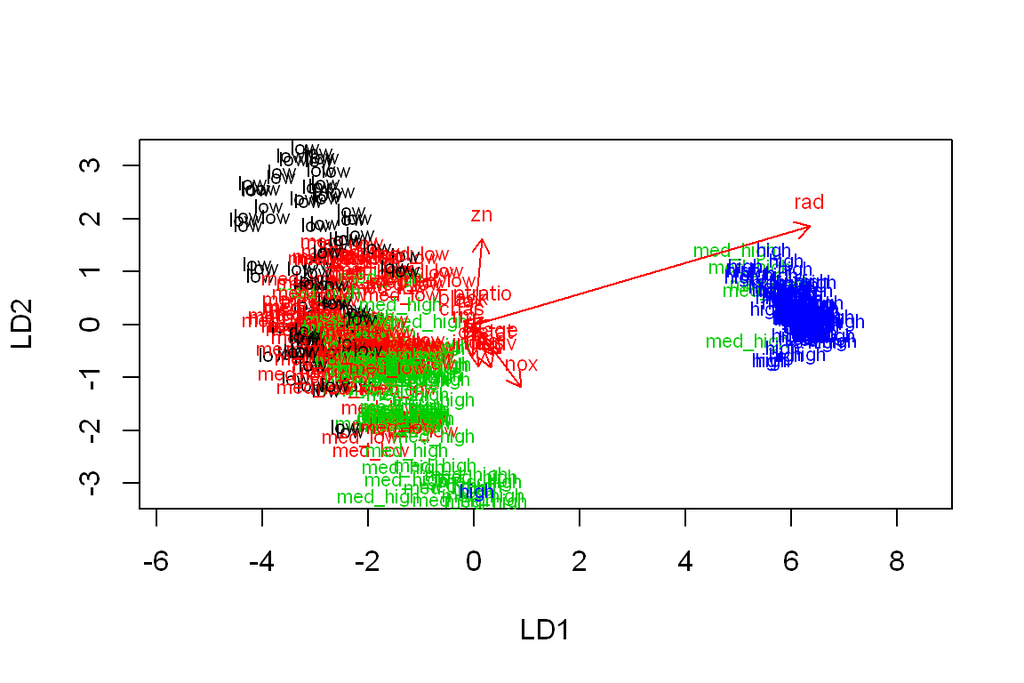

```r
lda.graph <- function(x, myscale = 1, arrow_heads = 0.1, color = "red", tex = 0.75, choices = c(1,2)){
  heads <- coef(x)
  arrows(x0 = 0, y0 = 0,
         x1 = myscale * heads[,choices[1]],
         y1 = myscale * heads[,choices[2]], col=color, length = arrow_heads)
  text(myscale * heads[,choices], labels = row.names(heads),
       cex = tex, col=color, pos=3)
}
classes <- as.numeric(train$crime)
plot(lda.fit, dimen = 2, col = classes, pch = classes)
lda.graph(lda.fit, myscale = 2)
```

```r
lda.pred <- predict(lda.fit, newdata = test)
table(correct = correct_classes, predicted = lda.pred$class)
```

```
##           predicted
## correct    low med_low med_high high
##   low       15       8        2    0
##   med_low    3      15        4    0
##   med_high   0       7       20    1
##   high       0       0        0   27
```

## Distances between observations and k-means

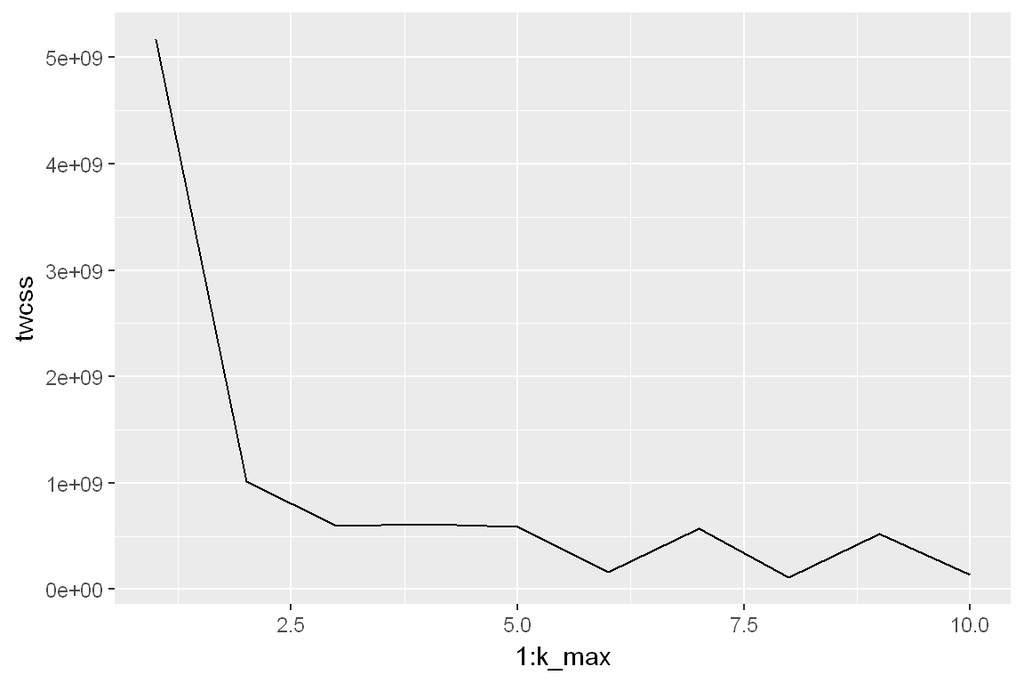

```r
km <- kmeans(dist_eu, centers = 5)
set.seed(123)
k_max <- 10
twcss <- sapply(1:k_max, function(k){kmeans(dist_eu, k)$tot.withinss})
qplot(x = 1:k_max, y = twcss, geom = 'line')
```

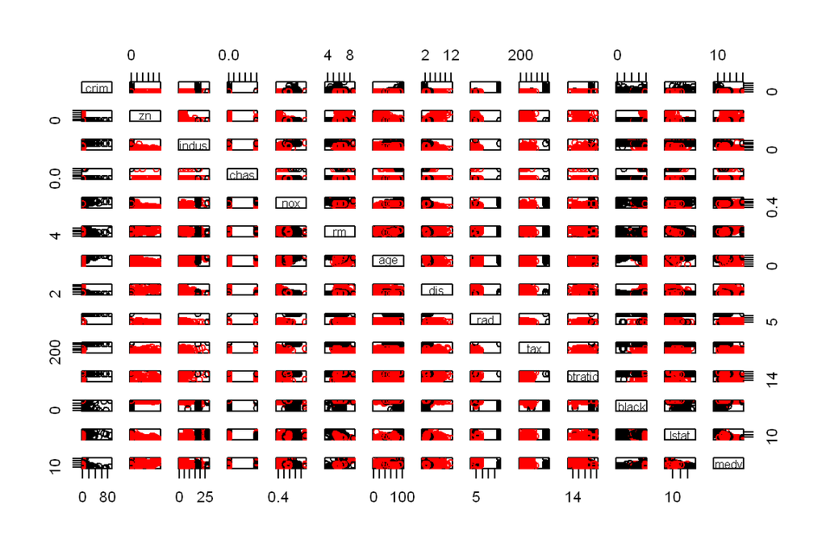

```r
km <-kmeans(dist_eu, centers = 2)
pairs(Boston, col = km$cluster)
```

From the q-plot, we can clearly see that 2 is the optimal number of clusters. Therefore, I created the plot to visualize the clusters. As we can see here, two clusters don’t optimally differentiate for all variables: e.g. in the relation between “nox” and “lstat” we can see that members of the clusters are very mixed up.

# Week 5

## Loading exploring the data

The “human” dataset consists of 8 variables that describe different aspects of human development with a strong emphasis on equality between men and women. The variables indexing equality are mainly the share of women with secondary education compared to men (“Edu2.FM”), the proportion of women in the labor force compared to proportion of men in the laborforce (“Labo.FM”), and the share of female members of parliament (“Parli.F”).

## Summary and overview

```r
summary(human)
```

```
##     Edu2.FM          Labo.FM          Edu.Exp         Life.Exp
##  Min.   :0.1717   Min.   :0.1857   Min.   : 5.40   Min.   :49.00
##  1st Qu.:0.7264   1st Qu.:0.5984   1st Qu.:11.25   1st Qu.:66.30
##  Median :0.9375   Median :0.7535   Median :13.50   Median :74.20
##  Mean   :0.8529   Mean   :0.7074   Mean   :13.18   Mean   :71.65
##  3rd Qu.:0.9968   3rd Qu.:0.8535   3rd Qu.:15.20   3rd Qu.:77.25
##  Max.   :1.4967   Max.   :1.0380   Max.   :20.20   Max.   :83.50
##       GNI            Mat.Mor         Ado.Birth         Parli.F
##  Min.   :   581   Min.   :   1.0   Min.   :  0.60   Min.   : 0.00
##  1st Qu.:  4198   1st Qu.:  11.5   1st Qu.: 12.65   1st Qu.:12.40
##  Median : 12040   Median :  49.0   Median : 33.60   Median :19.30
##  Mean   : 17628   Mean   : 149.1   Mean   : 47.16   Mean   :20.91
##  3rd Qu.: 24512   3rd Qu.: 190.0   3rd Qu.: 71.95   3rd Qu.:27.95
##  Max.   :123124   Max.   :1100.0   Max.   :204.80   Max.   :57.50
```

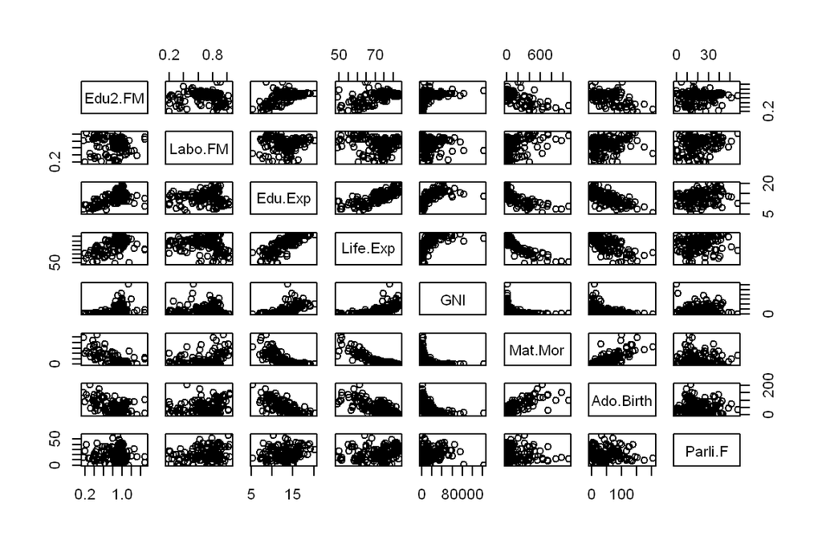

```r
pairs(human)
```

```r
cor_matrix <- cor(human) %>% round (digits = 2)
cor_matrix
```

```
##           Edu2.FM Labo.FM Edu.Exp Life.Exp   GNI Mat.Mor Ado.Birth Parli.F
## Edu2.FM      1.00    0.01    0.59     0.58  0.43   -0.66     -0.53    0.08
## Labo.FM      0.01    1.00    0.05    -0.14 -0.02    0.24      0.12    0.25
## Edu.Exp      0.59    0.05    1.00     0.79  0.62   -0.74     -0.70    0.21
## Life.Exp     0.58   -0.14    0.79     1.00  0.63   -0.86     -0.73    0.17
## GNI          0.43   -0.02    0.62     0.63  1.00   -0.50     -0.56    0.09
## Mat.Mor     -0.66    0.24   -0.74    -0.86 -0.50    1.00      0.76   -0.09
## Ado.Birth   -0.53    0.12   -0.70    -0.73 -0.56    0.76      1.00   -0.07
## Parli.F      0.08    0.25    0.21     0.17  0.09   -0.09     -0.07    1.00
```

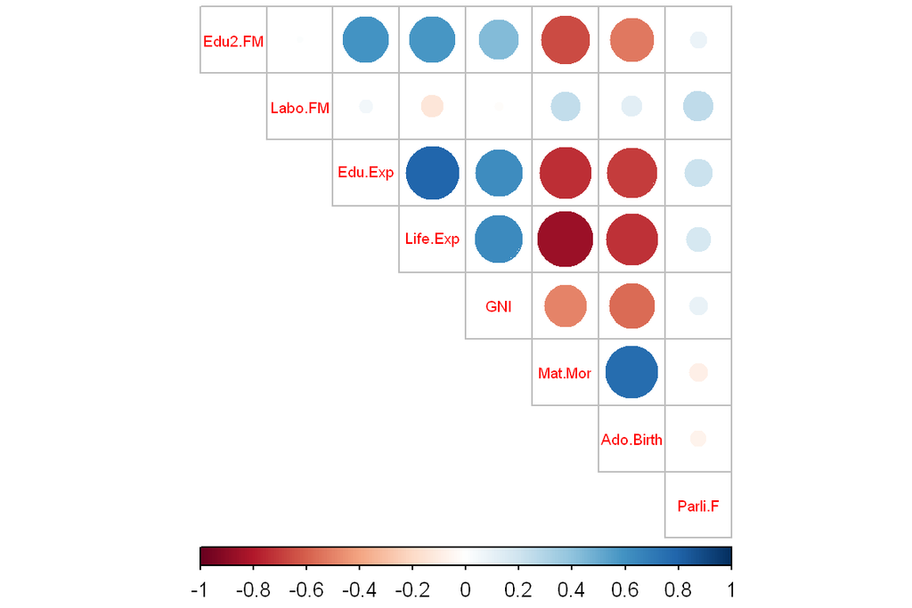

```r
corrplot(cor_matrix, method="circle", type = "upper", cl.pos = "b", tl.pos = "d", tl.cex = 0.6)
```

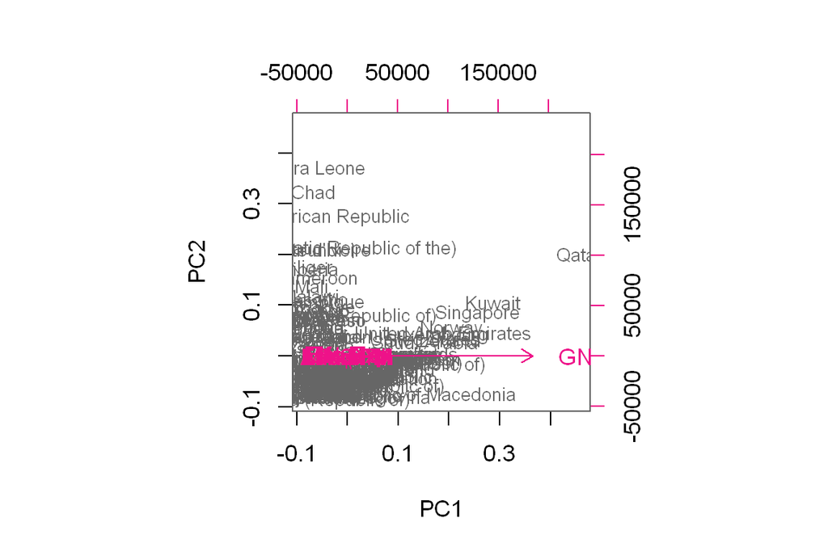

```r
pca_human <- prcomp(human)
biplot(pca_human, choices = 1:2, cex = c(0.8, 1), col = c("grey40", "deeppink2"))
```

```r
s <- summary(pca_human)
s
```

```
## Importance of components:
##                              PC1      PC2   PC3   PC4   PC5   PC6    PC7
## Standard deviation     1.854e+04 185.5219 25.19 11.45 3.766 1.566 0.1912
## Proportion of Variance 9.999e-01   0.0001  0.00  0.00 0.000 0.000 0.0000
## Cumulative Proportion  9.999e-01   1.0000  1.00  1.00 1.000 1.000 1.0000
##                           PC8
## Standard deviation     0.1591
## Proportion of Variance 0.0000
## Cumulative Proportion  1.0000
```

```r
pca_pr <- round(100*s$importance[2, ], digits = 1)
pca_pr
```

```
## PC1 PC2 PC3 PC4 PC5 PC6 PC7 PC8
## 100   0   0   0   0   0   0   0
```

```r
paste0(names(pca_pr), " (", pca_pr, "%)")
```

```
## [1] "PC1 (100%)" "PC2 (0%)"   "PC3 (0%)"   "PC4 (0%)"   "PC5 (0%)"
## [6] "PC6 (0%)"   "PC7 (0%)"   "PC8 (0%)"
```

```r
pc_lab <- paste0(names(pca_pr), " (", pca_pr, "%)")
pc_lab
```

```
## [1] "PC1 (100%)" "PC2 (0%)"   "PC3 (0%)"   "PC4 (0%)"   "PC5 (0%)"
## [6] "PC6 (0%)"   "PC7 (0%)"   "PC8 (0%)"
```

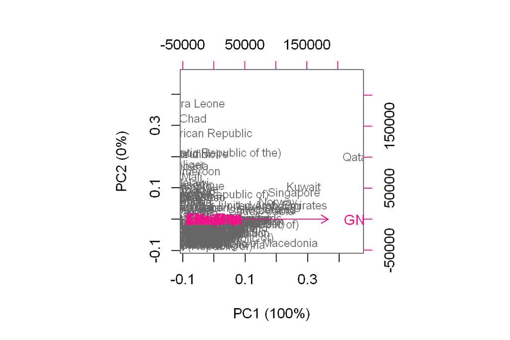

```r
# draw a biplot
biplot(pca_human, cex = c(0.8, 1), col = c("grey40", "deeppink2"), xlab = pc_lab[1], ylab = pc_lab[2])
```

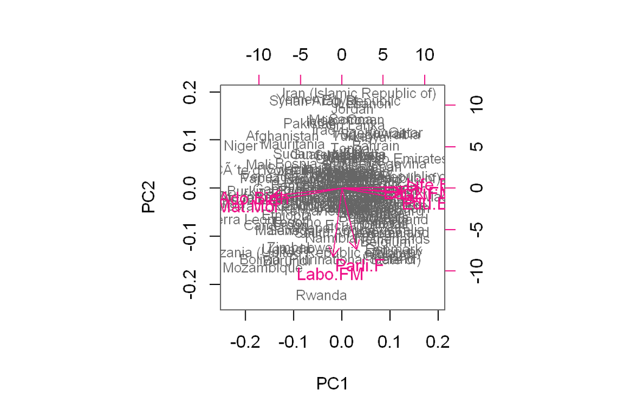

```r
human <- scale (human)
pca_human <- prcomp(human)
biplot(pca_human, choices = 1:2, cex = c(0.8, 1), col = c("grey40", "deeppink2"))
```

```r
s <- summary(pca_human)
s
```

```
## Importance of components:
##                           PC1    PC2     PC3     PC4     PC5     PC6
## Standard deviation     2.0708 1.1397 0.87505 0.77886 0.66196 0.53631
## Proportion of Variance 0.5361 0.1624 0.09571 0.07583 0.05477 0.03595
## Cumulative Proportion  0.5361 0.6984 0.79413 0.86996 0.92473 0.96069
##                            PC7     PC8
## Standard deviation     0.45900 0.32224
## Proportion of Variance 0.02634 0.01298
## Cumulative Proportion  0.98702 1.00000
```

```r
pca_pr <- round(100*s$importance[2, ], digits = 1)
pca_pr
```

```
##  PC1  PC2  PC3  PC4  PC5  PC6  PC7  PC8
## 53.6 16.2  9.6  7.6  5.5  3.6  2.6  1.3
```

```r
paste0(names(pca_pr), " (", pca_pr, "%)")
```

```
## [1] "PC1 (53.6%)" "PC2 (16.2%)" "PC3 (9.6%)"  "PC4 (7.6%)"  "PC5 (5.5%)"
## [6] "PC6 (3.6%)"  "PC7 (2.6%)"  "PC8 (1.3%)"
```

```r
pc_lab <- paste0(names(pca_pr), " (", pca_pr, "%)")
pc_lab
```

```
## [1] "PC1 (53.6%)" "PC2 (16.2%)" "PC3 (9.6%)"  "PC4 (7.6%)"  "PC5 (5.5%)"
## [6] "PC6 (3.6%)"  "PC7 (2.6%)"  "PC8 (1.3%)"
```

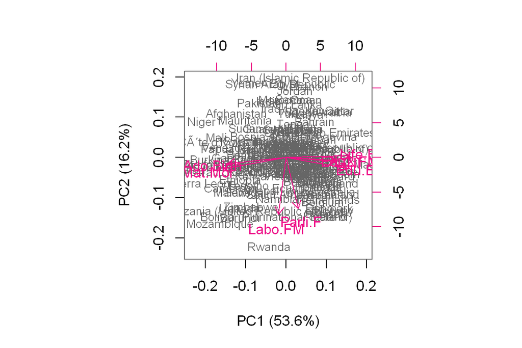

```r
# draw a biplot
biplot(pca_human, cex = c(0.8, 1), col = c("grey40", "deeppink2"), xlab = pc_lab[1], ylab = pc_lab[2])
```

After standardizing the data, the analysis makes much more sense. We can see that PC1 accounts for 53.6% of the variance and PC2 for 16.2%. We can also see that all variables but *Labo.FM* and *Parli.F* differentiate between countries on the PC1 dimension. *Labo.FM* and *Parli.F* differentiate on the PC 2 dimension and are correlated: the proportion of women in the workforce and the share of female MPs. This indicates that we can differentiate between countries in regard to their representation of women in the labor market and parliament on the one hand, and all other variables in the dataset on the other hand. We might therefore consider PC2 as “female representation” and PC1 as “health and education development”.

## Tea dataset

```r
library(FactoMineR)
library(tidyr)
library(dplyr)
data(tea)
str(tea)
```

```
## 'data.frame':    300 obs. of  36 variables:
##  $ breakfast       : Factor w/ 2 levels "breakfast","Not.breakfast": 1 1 2 2 1 2 1 2 1 1 ...
##  $ tea.time        : Factor w/ 2 levels "Not.tea time",..: 1 1 2 1 1 1 2 2 2 1 ...
##  $ evening         : Factor w/ 2 levels "evening","Not.evening": 2 2 1 2 1 2 2 1 2 1 ...
##  $ lunch           : Factor w/ 2 levels "lunch","Not.lunch": 2 2 2 2 2 2 2 2 2 2 ...
##  $ dinner          : Factor w/ 2 levels "dinner","Not.dinner": 2 2 1 1 2 1 2 2 2 2 ...
##  $ always          : Factor w/ 2 levels "always","Not.always": 2 2 2 2 1 2 2 2 2 2 ...
##  $ home            : Factor w/ 2 levels "home","Not.home": 1 1 1 1 1 1 1 1 1 1 ...
##  $ work            : Factor w/ 2 levels "Not.work","work": 1 1 2 1 1 1 1 1 1 1 ...
##  $ tearoom         : Factor w/ 2 levels "Not.tearoom",..: 1 1 1 1 1 1 1 1 1 2 ...
##  $ friends         : Factor w/ 2 levels "friends","Not.friends": 2 2 1 2 2 2 1 2 2 2 ...
##  $ resto           : Factor w/ 2 levels "Not.resto","resto": 1 1 2 1 1 1 1 1 1 1 ...
##  $ pub             : Factor w/ 2 levels "Not.pub","pub": 1 1 1 1 1 1 1 1 1 1 ...
##  $ Tea             : Factor w/ 3 levels "black","Earl Grey",..: 1 1 2 2 2 2 2 1 2 1 ...
##  $ How             : Factor w/ 4 levels "alone","lemon",..: 1 3 1 1 1 1 1 3 3 1 ...
```

[output cut: 22 more lines]

```r
dim(tea)
```

```
## [1] 300  36
```

The “tea” dataset contains 300 observations of 36 variables indicating participants’ habits concerning tea consumption (How British!). I will focus on a few key variables here that I find interesting: “effect.on.health”, “relaxing”, “exciting”, “slimming”, and “sophisticated” since I’m interested in why people drink tea.

```r
keep <- c("effect.on.health", "relaxing", "exciting", "slimming", "sophisticated")
tea <- dplyr::select(tea, one_of(keep))
str(tea)
```

```
## 'data.frame':    300 obs. of  5 variables:
##  $ effect.on.health: Factor w/ 2 levels "effect on health",..: 2 2 2 2 2 2 2 2 2 2 ...
##  $ relaxing        : Factor w/ 2 levels "No.relaxing",..: 1 1 2 2 2 2 2 2 2 2 ...
##  $ exciting        : Factor w/ 2 levels "exciting","No.exciting": 2 1 2 2 2 2 2 2 2 2 ...
##  $ slimming        : Factor w/ 2 levels "No.slimming",..: 1 1 1 1 1 1 1 1 1 1 ...
##  $ sophisticated   : Factor w/ 2 levels "Not.sophisticated",..: 1 1 1 2 1 1 1 2 2 1 ...
```

```r
dim(tea)
```

```
## [1] 300   5
```

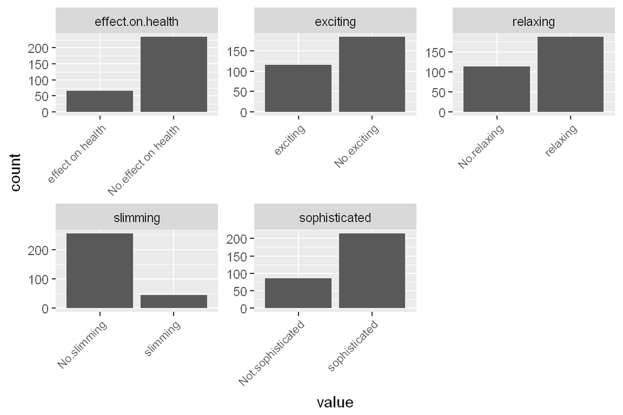

```r
gather(tea) %>% ggplot(aes(value)) + geom_bar() + theme(axis.text.x = element_text(angle = 45, hjust = 1, size = 8)) + facet_wrap("key", scales = "free")
```

We can see here that most people think it’s sophisticated, and relaxing. Most people don’t find it exciting, expect an effect on health or think it is slimming.